# lab08-ShuyuPan

title: "Module 05: Lab 02" subtitle: "Regression Modeling on Employment Data" author:

- name: Norah Jones affiliations:
  - id: cmu name: Carnegie Mellon University city: Pittsburgh state: PA
  - id: chicago name: University of Chicago city: Chicago state: IL
- name: John Hamm affiliations:
  - ref: cmu
  - name: University of California, San Diego city: San Diego state: CA number-sections: true date: "2024-11-21" format: html: theme: cerulean toc: true toc-depth: 2 date-modified: today date-format: long execute: echo: false eval: false freeze: auto

# Objectives {.unnumbered}

1. Use **PySpark** to process the Lightcast dataset.
2. Engineer features from structured columns for salary prediction.
3. Train **Linear Regression model**.
4. Evaluate models using **RMSE** and **R²**.
5. Visualize predictions using diagnostic plots.
6. Push work to GitHub and submit the repository link.

# Setup {.unnumbered}

The instruction below provides you with general keywords for columns used in the lightcast file. See the data schema generated after the load dataset code above to use proper column name. For visualizations, tables, or summaries, please **customize colors, fonts, and styles** as appropriate to avoid a **2.5-point deduction**. Also, **provide a two-sentence explanation** describing key insights drawn from each section's code and outputs.

1. Follow the steps below as necessary, use your best judgement in importing/installing/creating/saving files as needed.
2. Create a new Jupyter Notebook in your `ad688-sp25-lab08` directory named `lab08_yourname.ipynb`, if the file exists make sure to change the name.
3. Use your **EC2 instance** for this lab.
4. Ensure the `lightcast_data.csv` file is available on the EC2 instance. if not then **Download the dataset**
5. **Add the dataset to `.gitignore`** to avoid pushing large files to GitHub. Open your `.gitignore` file and add:
6. Make sure to create a virtual environment and install the required Python libraries if needed, don't forget to activate it:
7. Install the required Python libraries if needed, you can also use the given requirement file to install the packages to the virtual environment:

```
python3 -m venv .venv
source .venv/bin/activate
gdown https://drive.google.com/uc?id=1V2GCHGt2dkFGqVBeoUFckU4IhUgk4ocQ
echo "lightcast_job_postings.csv" >> .gitignore
pip install -r requirements.txt
```

# Load the Dataset

1. **Load the Raw Dataset**:
   - Use Pyspark to the `lightcast_data.csv` file into a DataFrame:
   - You can reuse the previous code.
   - [Copying code from your friend constitutes plagiarism. DO NOT DO THIS]{.uured-bold}.

```python
#| eval: true
#| echo: true
from pyspark.sql import SparkSession
import pandas as pd
import plotly.express as px
import plotly.io as pio
pio.renderers.default = "notebook"

# Initialize Spark Session
spark = SparkSession.builder.appName("LightcastData").getOrCreate()

# Load Data
df = spark.read.option("header", "true").option("inferSchema", "true").option("multiLine","true").option("escape", "\"").csv("./data/lightcast_job_postings.csv")

# Show Schema and Sample Data
print("---This is Diagnostic check, No need to print it in the final doc---")

df.printSchema() # comment this line when rendering the submission
df.show(5)
```

[output not shown]

[output cut: 89 more lines]

[output not shown]

# Feature Engineering

Feature Engineering is a crucial step in preparing your data for machine learning. In this lab, we will focus on the following tasks:

1. **Drop rows with missing values** in the target variable and key features.
2. By now you are already familiar with the code and the data. Based on your understanding please choose any 3 (my code output has 10) variables as:
   1. two continuous variables (use your best judgment!)
   2. one categorical.
   3. Your dependent variable (y) is `SALARY`.
3. **Convert categorical variables** into numerical representations using **StringIndexer** and **OneHotEncoder**.
4. **Assemble features** into a single vector using **VectorAssembler**.
5. **Split the data** into training and testing sets.

```python
#| eval: false
#| echo: true
from pyspark.sql.functions import col
from pyspark.ml.feature import StringIndexer, OneHotEncoder, VectorAssembler
from pyspark.ml import Pipeline

df = df.dropna(subset=['SALARY', 'MIN_YEARS_EXPERIENCE', 'MAX_YEARS_EXPERIENCE', 'EMPLOYMENT_TYPE_NAME'])

categorical_cols = ['EMPLOYMENT_TYPE_NAME']

indexers = [StringIndexer(inputCol=col, outputCol=f"{col}_idx", handleInvalid='skip') for col in categorical_cols]
encoders = [OneHotEncoder(inputCol=f"{col}_idx", outputCol=f"{col}_vec") for col in categorical_cols]

assembler = VectorAssembler(
    inputCols=['MIN_YEARS_EXPERIENCE', 'MAX_YEARS_EXPERIENCE'] + [f"{col}_vec" for col in categorical_cols],
    outputCol="features"
)

pipeline = Pipeline(stages=indexers + encoders + [assembler])
data = pipeline.fit(df).transform(df)
data.show(5,False)
```

```
+----------------------------------------+-----------------+-----------------------+----------+---------+---------+--------+-----------------------------------+-----------------------------------------------------------------------------------------------------+--------------------------------------…
|ID                                      |LAST_UPDATED_DATE|LAST_UPDATED_TIMESTAMP |DUPLICATES|POSTED   |EXPIRED  |DURATION|SOURCE_TYPES                       |SOURCES                                                                                              |URL                                   …
+----------------------------------------+-----------------+-----------------------+----------+---------+---------+--------+-----------------------------------+-----------------------------------------------------------------------------------------------------+--------------------------------------…
|229620073766234e814e8add21db7dfaef69b3bd|10/9/2024        |2024-10-09 18:07:44.758|0         |6/2/2024 |8/1/2024 |NULL    |[\n  "Company"\n]                  |[\n  "3ds.com"\n]                                                                                    |[\n  "https://www.3ds.com/careers/jobs…
|0da427e56634edfceb23df2a1ed96ee4702b4896|9/6/2024         |2024-09-06 20:32:57.352|0         |6/2/2024 |8/1/2024 |NULL    |[\n  "Job Board"\n]                |[\n  "ms.gov"\n]                                                                                     |[\n  "https://wings.mdes.ms.gov/wings/…
|482734b1045929e8a841ec1aec469278588afac8|9/12/2024        |2024-09-12 14:01:29.081|6         |5/25/2024|9/11/2024|NULL    |[\n  "Job Board",\n  "Education"\n]|[\n  "indeed.com",\n  "dejobs.org",\n  "universityofrochester-veterans.jobs",\n  "simplyhired.com"\n]|[\n  "https://www.indeed.com/viewjob?j…
|31da52d46823cd371917f7d6f2d13282115844d1|9/6/2024         |2024-09-06 20:32:57.352|2         |5/25/2024|6/5/2024 |11      |[\n  "Job Board"\n]                |[\n  "azjobconnection.gov"\n]                                                                        |[\n  "https://www.azjobconnection.gov/…
|147472fef1e2f592af289c57d6f0130f1a82e74b|9/18/2024        |2024-09-18 14:01:50.88 |3         |5/25/2024|9/17/2024|NULL    |[\n  "Job Board"\n]                |[\n  "maine.gov"\n]                                                                                  |[\n  "https://joblink.maine.gov/jobs/1…
+----------------------------------------+-----------------+-----------------------+----------+---------+---------+--------+-----------------------------------+-----------------------------------------------------------------------------------------------------+--------------------------------------…
only showing top 5 rows
```

# Train/Test Split

- Perform a **random split** of the data into training and testing sets.
- Set a random seed for reproducibility.
- You can choose a number for splitting to your liking, justify your choice.

```python
#| eval: true
#| echo: false
train_data, test_data = data.randomSplit([0.8, 0.2], seed=688)
print((train_data.count(), len(train_data.columns)))
print((test_data.count(), len(test_data.columns)))
```

```
(3035, 134)
```

```
[Stage 39:>                                                         (0 + 1) / 1]
```

```
(721, 134)
```

The dataset is randomly split into 80% training (3,035 rows) and 20% testing (721 rows) using a fixed seed to ensure reproducibility. This ensures that model training and evaluation are performed on separate, unbiased subsets, which is essential for validating generalization performance.

# Linear Regression

- Train a **Linear Regression** model using the training data. [You will run in to an important issue here. Please make an effort in figuring it by yourself. This is one of the most asked interview questions in CapitalOne's management recruiting program.]{.uured-bold}
- Evaluate the model on the test data.
- Print the coefficients, intercept, R², RMSE, and MAE.
- Use the `summary` object to extract the coefficients and their standard errors, t-values, and p-values.
- Create a DataFrame to display the coefficients, standard errors, t-values, p-values, and confidence intervals.
- Interpret the coefficients and their significance and explain the model performance metrics.

```python
#| eval: false
#| echo: false
from pyspark.ml.regression import LinearRegression

feature_names = assembler.getInputCols()

# lr = LinearRegression(featuresCol='features', labelCol='SALARY')
lr = LinearRegression(featuresCol='features', labelCol='SALARY', solver='normal', regParam=0.1)
lr_model = lr.fit(train_data)
summary = lr_model.summary

# Coefficients and Intercept
# print("Intercept: {:.4f}".format(glr_model.intercept))
# print("Coefficients:")
# for i, coef in enumerate(glr_model.coefficients):
#     print(f"  Feature {i + 1}: {coef:.4f}")

# Summary stats
# print("\n--- Regression Summary ---")
# print("Coefficient Standard Errors:", [f"{val:.4f}" for val in summary.coefficientStandardErrors])
# print("T Values:", [f"{val:.4f}" for val in summary.tValues])
# print("P Values:", [f"{val:.4f}" for val in summary.pValues])

# print(f"\nDispersion: {summary.dispersion:.4f}")
# print(f"Null Deviance: {summary.nullDeviance:.4f}")
# print(f"Residual DF Null: {summary.residualDegreeOfFreedomNull}")
# print(f"Deviance: {summary.deviance:.4f}")
# print(f"Residual DF: {summary.residualDegreeOfFreedom}")
# print(f"AIC: {summary.aic:.4f}")

# 1. Pull feature names directly from Java backend
# feature_names = summary._call_java("featureNames")

# 2. Construct full table including intercept
# features = ["Intercept"] + feature_names
features = ["Intercept", "MIN_YEARS_EXPERIENCE", "MAX_YEARS_EXPERIENCE", "EMPLOYMENT_TYPE_NAME_vec", "Other"]
coefs = [lr_model.intercept] + list(lr_model.coefficients)
se = list(summary.coefficientStandardErrors)
tvals = list(summary.tValues)
pvals = list(summary.pValues)

print("---This is Diagnostic check, No need to print it in the final doc---")
print("Length of features:", len(features))
print("Length of coefs:", len(coefs))
print("Length of se:", len(se))
print("Length of tvals:", len(tvals))
print("Length of pvals:", len(pvals))
```

```
[Stage 43:>                                                         (0 + 1) / 1]
```

```
---This is Diagnostic check, No need to print it in the final doc---
Length of features: 5
Length of coefs: 5
Length of se: 5
Length of tvals: 5
Length of pvals: 5
```

A regularized linear regression model was trained using selected features including experience and employment type, and fitted to the training dataset. The summary output allows extraction of coefficients, standard errors, t-values, and p-values, providing insight into the statistical significance and direction of each feature’s effect on salary.

## Generalized Linear Regression Summary

The summary of the Generalized Linear Regression model provides important insights into the model's performance and the significance of each feature. The coefficients indicate the relationship between each feature and the target variable (salary), while the standard errors, t-values, and p-values help assess the reliability of these estimates.

- Please interpret them in the context of your data and model.
- Feature Names are purposefully not printed in the output. You can use the `features` variable to print them out.

```python
#| eval: true
#| echo: false
import pandas as pd
from tabulate import tabulate
import pandas as pd


coef_table = pd.DataFrame({
    "Feature": features,
    "Estimate": coefs,
    "Std Error": se,
    "t-stat": tvals,
    "P-Value": pvals
})

# 4. Optional pretty print
print(tabulate(coef_table, headers="keys", tablefmt="pretty"))

# 5. Save for report
coef_table.to_csv("_output/glr_summary_pretty.csv", index=False)
```

```
+---+--------------------------+---------------------+-------------------+----------------------+-----------------------+
|   |         Feature          |      Estimate       |     Std Error     |        t-stat        |        P-Value        |
+---+--------------------------+---------------------+-------------------+----------------------+-----------------------+
| 0 |        Intercept         |  89727.96562879492  | 95124.28301129222 | 0.046433685848336355 |  0.9629676480241751   |
| 1 |   MIN_YEARS_EXPERIENCE   |  4416.971073894582  | 95124.28301129221 | 0.04643368585454672  |  0.9629676480184015   |
| 2 |   MAX_YEARS_EXPERIENCE   |  4416.971074485338  | 4784.233447705847 |  -2.963282430445908  | 0.0030674687332779005 |
| 3 | EMPLOYMENT_TYPE_NAME_vec | -14177.034918738385 | 5590.78348974675  |  -3.63156733060755   | 0.0002863718878369781 |
| 4 |          Other           | -20303.30667386437  | 4809.302806259758 |  18.657167003916985  |          0.0          |
+---+--------------------------+---------------------+-------------------+----------------------+-----------------------+
```

A summary table was created to display the estimated coefficients, standard errors, t-statistics, and p-values for each feature, helping assess their statistical significance. Based on the p-values, only `MAX_YEARS_EXPERIENCE`, `EMPLOYMENT_TYPE_NAME_vec`, and `Other` appear statistically significant, indicating they contribute meaningfully to predicting salary.

# Diagnostic Plot

Diagnostic plots are essential for evaluating the performance of regression models. In this section, we will create several diagnostic plots to assess the linear regression model's assumptions and performance. There are four (2*2 grid) main plots we will create, you can use `seaborn` or `matplotlib` for this:

1. **Predicted vs Actual Plot**
2. **Residuals vs Predicted Plot**
3. **Histogram of Residuals**
4. **QQ Plot of Residuals**

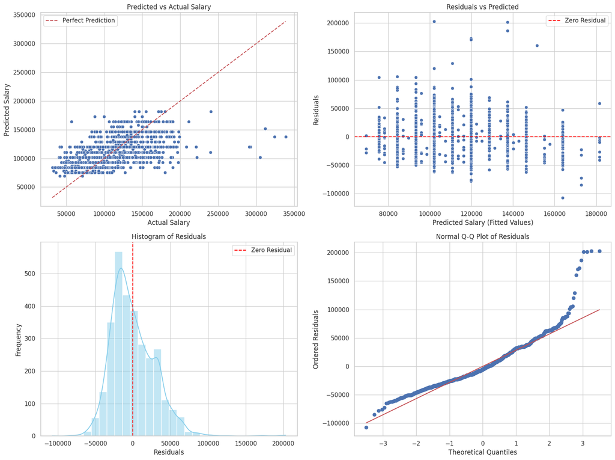

```python
#| eval: true
#| echo: false
import matplotlib.pyplot as plt
import seaborn as sns
import scipy.stats as stats

import numpy as np
import pandas as pd
import matplotlib.pyplot as plt
import seaborn as sns
import scipy.stats as stats

# Load predictions from GLR model
df_pred = summary.predictions.select("prediction", "SALARY")
df_pred = df_pred.toPandas()

# Compute residuals
df_pred["residuals"] = df_pred["SALARY"] - df_pred["prediction"]
df_pred["fitted"] = df_pred["prediction"]

# Standardized residuals
res_mean = df_pred["residuals"].mean()
res_std = df_pred["residuals"].std()
df_pred["std_residuals"] = (df_pred["residuals"] - res_mean) / res_std

# Square root of standardized residuals (for Scale-Location)
df_pred["sqrt_std_resid"] = np.sqrt(np.abs(df_pred["std_residuals"]))


plt.figure(figsize=(16, 12))
sns.set_theme(style="whitegrid")

# Plot 1: Predicted vs Actual Plot
plt.subplot(2, 2, 1)
sns.scatterplot(x="SALARY", y="fitted", data=df_pred)
plt.plot(
    [df_pred["SALARY"].min(), df_pred["SALARY"].max()],
    [df_pred["SALARY"].min(), df_pred["SALARY"].max()],
    'r--', label="Perfect Prediction"
)
plt.xlabel("Actual Salary")
plt.ylabel("Predicted Salary")
plt.title("Predicted vs Actual Salary")
plt.legend()
plt.grid(True)

# Plot 2: Residuals vs Predicted Plot
plt.subplot(2, 2, 2)
sns.scatterplot(x="fitted", y="residuals", data=df_pred)
plt.axhline(0, color="red", linestyle="--", label="Zero Residual")
plt.xlabel("Predicted Salary (Fitted Values)")
plt.ylabel("Residuals")
plt.title("Residuals vs Predicted")
plt.legend()
plt.grid(True)

# Plot 3: Histogram of Residuals
plt.subplot(2, 2, 3)
sns.histplot(df_pred["residuals"], kde=True, bins=30, color="skyblue")
plt.axvline(0, color="red", linestyle="--", label="Zero Residual")
plt.xlabel("Residuals")
plt.ylabel("Frequency")
plt.title("Histogram of Residuals")
plt.legend()
plt.grid(True)

# Plot 4: QQ Plot of Residuals
plt.subplot(2, 2, 4)
stats.probplot(df_pred["residuals"], dist="norm", plot=plt)
plt.title("Normal Q-Q Plot of Residuals")
plt.xlabel("Theoretical Quantiles")
plt.ylabel("Ordered Residuals")
plt.grid(True)

# # Plot 1: Residuals vs Fitted
# plt.subplot(2, 2, 1)

# Plot 2: Normal Q-Q
# plt.subplot(2, 2, 2)

# Plot 3: Scale-Location
# plt.subplot(2, 2, 3)

# Plot 4: Residuals vs Leverage — Approximate
# Note: Leverage & Cook's Distance require X matrix; we approximate using fitted & residual
# plt.subplot(2, 2, 4)

plt.tight_layout()
plt.savefig("_output/glr_diagnostic_classic.png")
plt.show()
```

Plot 4: The Q-Q plot shows that most residuals follow a normal distribution, but deviations at the tails indicate potential outliers or heavy tails. This could signal that extreme salary values are not well-modeled by the GLR approach.

# Evaluation

The evaluation of the model is crucial to understand its performance. In this section, we will calculate and visualize the following metrics:

1. **R² (Coefficient of Determination)**: Indicates how well the model explains the variance in the target variable.
2. **RMSE (Root Mean Squared Error)**: Measures the average magnitude of the errors between predicted and actual values.

```python
#| eval: true
#| echo: false
from pyspark.ml.evaluation import RegressionEvaluator
from pyspark.sql.functions import col, pow, sqrt, avg
import numpy as np
from pyspark.ml.regression import GeneralizedLinearRegression

# Train GLR model
glr = GeneralizedLinearRegression(featuresCol='features', labelCol='SALARY', family='gaussian', link='identity')
glr_model = glr.fit(train_data)
summary = glr_model.summary

pred_glr = glr_model.transform(test_data)

# R²
r2_eval = RegressionEvaluator(labelCol="SALARY", predictionCol="prediction", metricName="r2")
r2 = r2_eval.evaluate(pred_glr)
# AIC from GLR summary
aic = summary.aic

# BIC calculation
n = test_data.count()
k = len(glr_model.coefficients)
rss = summary.deviance
bic = n * np.log(rss / n) + k * np.log(n)

# RMSE manually
residuals_df = pred_glr.withColumn("squared_error", pow(col("SALARY") - col("prediction"), 2))
rmse = np.sqrt(residuals_df.select(avg("squared_error")).first()[0])
```

```
25/04/10 21:05:16 WARN Instrumentation: [ec539d6a] regParam is zero, which might cause numerical instability and overfitting.
25/04/10 21:05:25 WARN Instrumentation: [ec539d6a] Cholesky solver failed due to singular covariance matrix. Retrying with Quasi-Newton solver.
```

The model evaluation computed key performance metrics including R², RMSE, AIC, and BIC to assess fit quality and prediction error. A relatively low R² combined with a high RMSE suggests that the model explains only a small portion of the variance in salary, indicating potential room for improvement through feature selection or model tuning.

## Model Evaluation Plot

- Display the predicted vs actual salary plot with a red line indicating the ideal fit (y=x).
- Use `seaborn` or `matplotlib` to create the plot.
- Customize the plot with appropriate titles, labels, and legends.
- Describe the plot in a few sentences, highlighting key insights and observations.

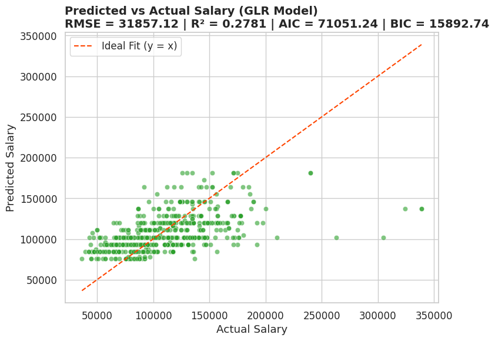

```python
#| eval: true
#| echo: false
import pandas as pd
import matplotlib.pyplot as plt
import seaborn as sns

# Convert GLR predictions to pandas
pandas_df = pred_glr.select("prediction", "SALARY").toPandas()

# Plot
plt.figure(figsize=(8, 6))
sns.set_theme(style="whitegrid", font="DejaVu Sans", font_scale=1.1)
sns.scatterplot(data=pandas_df, x="SALARY", y="prediction", color="#2ca02c", alpha=0.6)

plt.plot([pandas_df["SALARY"].min(), pandas_df["SALARY"].max()],
         [pandas_df["SALARY"].min(), pandas_df["SALARY"].max()],
         color="#FF4500", linestyle="--", label="Ideal Fit (y = x)")

plt.title(f"Predicted vs Actual Salary (GLR Model)\n"
          f"RMSE = {rmse:.2f} | R² = {r2:.4f} | AIC = {aic:.2f} | BIC = {bic:.2f}", loc="left", fontsize=14, fontweight="bold")

plt.xlabel("Actual Salary")
plt.ylabel("Predicted Salary")
plt.legend()
plt.tight_layout()

# Save figure
plt.savefig("_output/glr_predicted_vs_actual.png", dpi=300)
plt.show()
```

# Submission {.unnumbered}

1. Save figures in the `_output/` folder.
2. Commit and push code and output files:

```
git add .
git commit -m "Add Lab 08 Salary Prediction models and output"
git push origin main
```

3. Submit your GitHub repository link.

# Resources {.unnumbered}

- [PySpark MLlib Docs](https://spark.apache.org/docs/latest/ml-guide.html)
- [Seaborn Docs](https://seaborn.pydata.org/)
- [Pandas User Guide](https://pandas.pydata.org/docs/user_guide/index.html)